# RNA Seq miniproject

Trent Gutierrez

2022-09-15

## Introduction

### Research question

This RNA-Seq data investigates genes from neurons differentiated from induced pluripotent stem cells (iPSCs). the **patient** group includes individuals who have either 2q11.2 Deletion Syndrome (22q11.2 DS) or schizoaffective disorder (SAD), this means these individuals are at high risk to developing schizophrenia. This data includes these patient’s RNA-Seq data and multiple controls. This R markdown will use the rse data provided by the respective scientist and will conduct analysis to make our own conclusion based off the data.

### Data Input

This code was provided by recount2 and was adjusted to download the rse data for the **SRP022028** experiment. The code downloads the `rse_gene.Rdata` file into a folder named “SRP022028” placed into the working directory. the `rse_gene` data is scaled into the `rse` data.

```r
url <- download_study("SRP022028")
load(file.path("SRP022028", 'rse_gene.Rdata'))
rse <- scale_counts(rse_gene)
```

This code starts off by assigning the variables `projects` and `conditions` which are then combined into the `metadata` data frame which then has the row names from the `rse` column data. Why do we need this metadata? It mostly is used to help label what each sample is.

```r
projects <- c("SRP022028","SRP022028","SRP022028","SRP022028",
             "SRP022028","SRP022028","SRP022028","SRP022028")

conditions <- c("patient","patient","patient","patient",
                "control","control","control","control")

metadata <- data.frame(projects,conditions)

rownames(metadata) <- c("SRR836527","SRR836528", "SRR836529", "SRR836530",
                        "SRR836531" ,"SRR836532" ,"SRR836533" ,"SRR836534")
```

The way we found out the idenfiers like `project` and `conditions` was identied by using `colData(rse)` to look at all our columns and try to identify what sample belongs to which condition.

```r
metadata %>%
  kbl(caption = "Metadata for SRP022028") %>%
  kable_styling(bootstrap_options = "striped", full_width = T, html_font = "Cambria")
```

Metadata for SRP022028

|  | projects | conditions |
| --- | --- | --- |
| SRR836527 | SRP022028 | patient |
| SRR836528 | SRP022028 | patient |
| SRR836529 | SRP022028 | patient |
| SRR836530 | SRP022028 | patient |
| SRR836531 | SRP022028 | control |
| SRR836532 | SRP022028 | control |
| SRR836533 | SRP022028 | control |
| SRR836534 | SRP022028 | control |

To allow further statistical analysis the `colData()` function was used to view information in `rse` and we can see with the “characteristics” column where our *patient* and *control* samples are indicated. This leads to the addition of the `conditions` column into `rse` so the `DESeq2()` package can interpret the data. The next step is to turn the `rse` data into `dds` which stands for *DESeqDataSet* and then this dataset is ran through `DESeq()` to run the actual differential expression analysis.

```r
rse$condition <- conditions

dds <- DESeqDataSet(rse, design = ~condition)
dds <-DESeq(dds)
```

Once the differential expression analysis is complete we still have the `dds` but now it has a **results** function which is assigned to the variable `result` (for later graphs, `result` is also transformed into the data frame `result_dataframe` to make interpretation easier) This `result` variable holds very important information such as the **log2 fold change** and **wald test p-value** using the condition specified earlier *patient* vs *control*

```r
result <- results(dds)
result_dataframe <- as.data.frame(result)
```

## Results

### Signifcant Differentially Expressed Genes (DEGs)

Now we can start to explore our data, first we want to acquire the actually significantly DEGs from our `result` function. First step is to order the result section by the *p-value*. Next is to filter the results slightly by removing any genes that have a *p-adjusted* value higher than 0.05 (5%) we choose this value likely because it leaves just the genes that gives us around a 95% confidence of being actually significant. To visualize our selected significant DEGs a data table was constructed.

```r
orderedresults <- result[order(result$pvalue),]

sigresults <- subset(orderedresults, padj < 0.05)

sigresults_dataframe <- as.data.frame(sigresults)
datatable(sigresults_dataframe, class = 'cell-border stripe' ,
          colnames = c("ENSEMBL Name" = 1),
          caption = "Table 1: Patient vs Control Significant Genes")
```

| ENSEMBL Name | baseMean | log2FoldChange | lfcSE | stat | pvalue | padj |
| --- | --- | --- | --- | --- | --- | --- |
| ENSG00000100075.9 | 2019.57522252245 | -1.34016362268268 | 0.156917865981904 | -8.54054198543101 | 1.33593738131994e-17 | 3.47544109750383e-13 |
| ENSG00000242259.8 | 2281.34819694509 | -0.977337801797953 | 0.122370323704493 | -7.98672237035252 | 1.38573689160205e-15 | 1.80249726175137e-11 |
| ENSG00000184436.11 | 430.675550158079 | -1.32537783635309 | 0.184553040122222 | -7.18155515333338 | 6.89228688772216e-13 | 5.9767614461364e-09 |
| ENSG00000099899.14 | 695.465018263687 | -1.06803878189188 | 0.159856092554028 | -6.68125164845317 | 2.36910000584084e-11 | 1.54080341629874e-07 |
| ENSG00000100084.14 | 1826.52711222392 | -1.10182442066174 | 0.167286373274915 | -6.58645650026149 | 4.50447445634304e-11 | 2.34367805963528e-07 |
| ENSG00000099949.18 | 2256.10044558927 | -0.9726001824332 | 0.156378218100567 | -6.21953744099912 | 4.98622633942826e-10 | 2.16194463700377e-06 |
| ENSG00000241973.10 | 3222.1003162847 | -0.900703517254253 | 0.145582678941963 | -6.18688654309846 | 6.13640968164022e-10 | 2.28055282668386e-06 |
| ENSG00000099901.16 | 2366.13957689925 | -1.13484037442008 | 0.184926548920674 | -6.1367087692037 | 8.42486267313275e-10 | 2.73966003051936e-06 |
| ENSG00000185608.8 | 301.037832859073 | -1.16087481202981 | 0.198194527596778 | -5.85724957245836 | 4.70595664925513e-09 | 1.3602829136708e-05 |
| ENSG00000040608.13 | 1124.13326248016 | -1.95469996348141 | 0.33843801940143 | -5.7756512313201 | 7.66560124216728e-09 | 1.99420616314982e-05 |

[output cut: 200 more lines]

### PCA Plot

A PCA plot is used to show how our samples cluster and if it correlates to the treatments. First we want to assign a new variable `vsd_dds` that just normalizes the count from the `dds` data. With the normalized data we construct our PCA graph with the groups *condition* and *sample* to help us identify which samples are which.

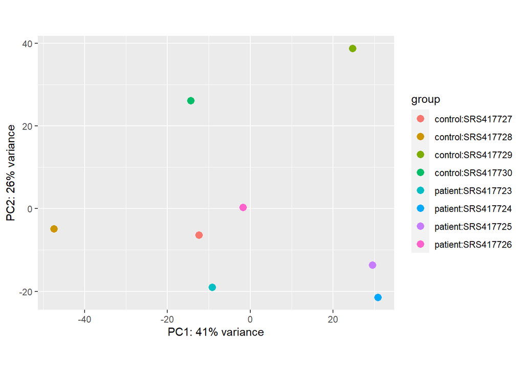

```r
vsd_dds <- vst(dds, blind = FALSE)

plotPCA(vsd_dds, intgroup = c("condition","sample"))
```

### Volcano Plot

Volcano plots give a bigger picture view of our data. First we add a new column *threshold* which returns TRUE/FALSE/NA depending if the row has a *p-adjusted* value less than 5% and this is assigned a new variable `result_dataframe_sig_marked`. This data is plotted.

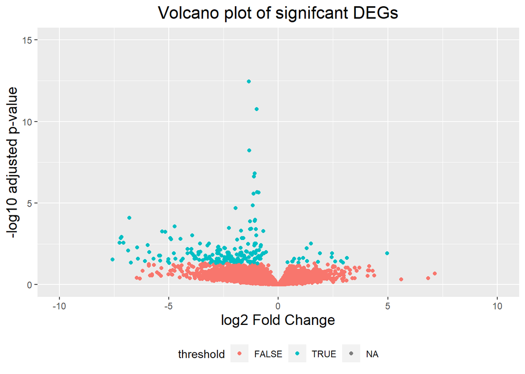

```r
result_dataframe_sig_marked <- data.frame(result_dataframe) %>%
  mutate(threshold = padj < 0.05)

ggplot(result_dataframe_sig_marked) +
  geom_point(aes(x = log2FoldChange, y= -log10(padj), col = threshold)) +
  xlim(c(-10,10))+
  ylim(c(0,15))+
  labs(
    x = "log2 Fold Change" ,
    y = "-log10 adjusted p-value" ,
    title = "Volcano plot of signifcant DEGs") +
  theme(legend.position = "bottom", plot.title = element_text(size = rel(1.5), hjust = 0.5),
              axis.title = element_text(size = rel(1.25)))
```

```r
top10DEGs <- sigresults[1:10,]
bot10DEGs <- sigresults[201:210,]
combinedDEGs <- rbind(top10DEGs,bot10DEGs)

normalized_dds_counts <- counts(dds, normalized=TRUE)
sig_norm_dds_counts <- normalized_dds_counts[rownames(combinedDEGs), ]

heat_colors <- brewer.pal(n = 6, name = "YlOrRd")
conflict_prefer("select","dplyr")
```

```
## [conflicted] Will prefer dplyr::select over any other package
```

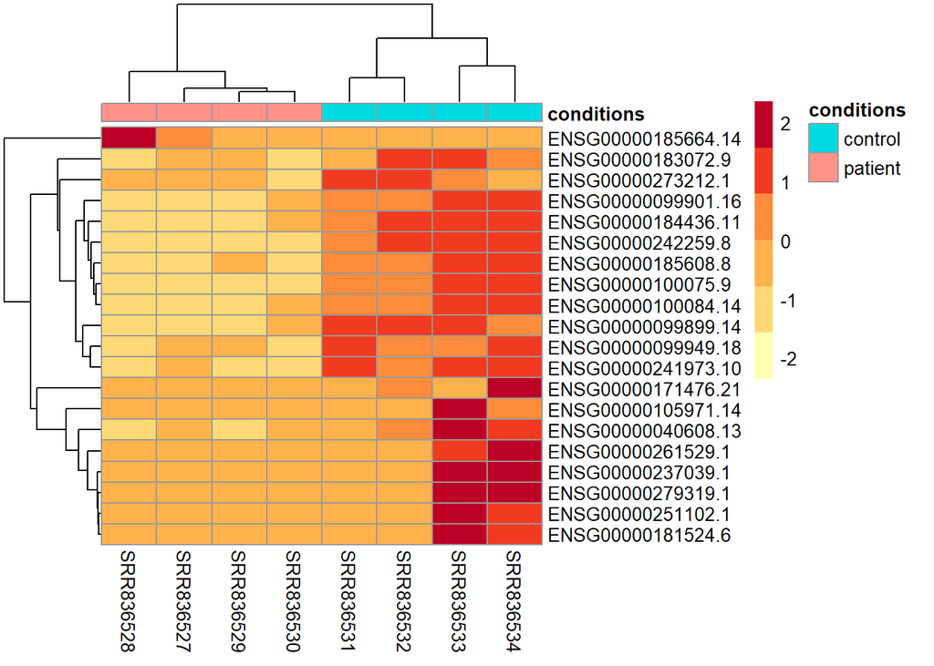

```r
pheatmap(sig_norm_dds_counts,
         color = heat_colors,
         cluster_rows = TRUE,
         show_rownames = TRUE,
         annotation =  select(metadata,conditions),
         scale = "row")
```

### GSEA

#### Clusterprofiler data set up

The first step of this data set up is to get our `EnsemblIDs` variable, this consist of the row names from the `result_dataframe` however most of them end with a decimal point and value, this causes errors so we use `str_replace` to get rid of the “.” and everything pass that point and replace it with nothing so our IDs are in the correct format for gene identification. Now we have to set up our gene list for the clusterprofiler, first it pulls the raw numbers from the result data frame for *log2FoldChange* then the Ensembl IDs are attached to this list. Then any *NA* values are removed, and finally the gene list is ordred from greatest to least, this is neccessary for the `gseGO` function to work correctly.

```r
EnsemblIDs <- rownames(result_dataframe)
EnsemblIDs <- str_replace(EnsemblIDs,
                           pattern = "\\..*",
                           replacement = "")

original_gene_list <- result_dataframe$log2FoldChange
names(original_gene_list) <- EnsemblIDs
gene_list <- na.omit(original_gene_list)
gene_list <- sort(gene_list, decreasing = TRUE)
```

`gseGO()` stands for *Gene Set Enrichment Analysis of Gene Ontology* This function will do our enrichment analysis. the gene list is the one we made above, the ont value allows you to analyze for Biological Processes, Molecular Function, and Cellular components, and if you want to see all 3 choose “ALL” like we did here. KeyType is dependent on the IDs we assigned our Gene list earlier, in this dataset we have Ensembl IDs. min and max GSSize gives us the minimum and maximum of the gene count in the list to be analyzed. the p-value cutoff is what the minimum p-value cut off is. P-Adjust method has a variety of different p-value adjusting techniques but for this data we want none of them. (Warning: The Data generated here is larger than anything else in this analysis)

```r
gse <- gseGO(geneList = gene_list , ont = "ALL",
             keyType = "ENSEMBL",
             minGSSize = 3, maxGSSize = 800,
             pvalueCutoff = 0.05, verbose = TRUE,
             OrgDb= "org.Hs.eg.db", pAdjustMethod = "none" )
```

#### gseaplot 2 graph

This graph is the top 5 pathways are visualized with the `gseaplot2()` function

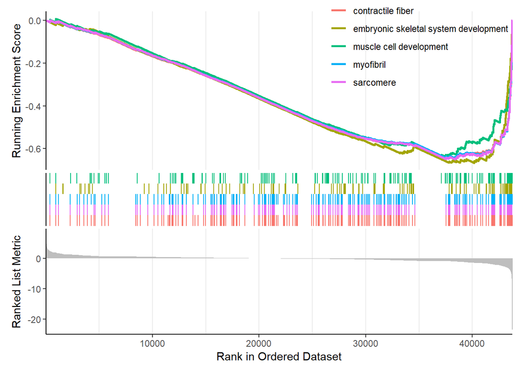

```r
GSEAplot <- gse %>%
  arrange(p.adjust)%>%
  gseaplot2(geneSetID = 1:5)
GSEAplot
```